# R-Ladies Nashville Kickoff Survey

```r
knitr::opts_chunk$set(message = FALSE, warning = FALSE)
```

Thank you all for your input! Below is a summary of responses from the R-Ladies Nashville kickoff survey.

```r
library(tidyverse)
library(shades)
library(pander)
## This R script has an API token in it, so it stays secret. Sssshhh. #goodpractice
source('export_kickoff_data.R')
## REDCap uses so many underscores, y'all
names(kickoff_data) <- gsub('_+', '_', names(kickoff_data))
## -- Variable renaming and creation ----------------------------------------------------------------
kickoff_data <- kickoff_data %>%
  ## Rename REDCap checkbox variables to be easier to work with
  rename(any_lunch = meeting_times_0,
         any_hh = meeting_times_1,
         any_evening = meeting_times_2,
         mon_lunch = which_weekdays_1,
         tues_lunch = which_weekdays_2,
         wed_lunch = which_weekdays_3,
         thurs_lunch = which_weekdays_4,
         fri_lunch = which_weekdays_5,
         mon_pm = which_weeknights_1,
         tues_pm = which_weeknights_2,
         wed_pm = which_weeknights_3,
         thurs_pm = which_weeknights_4,
         fri_pm = which_weeknights_5,
         sat_am = meeting_times_3,
         sat_pm = meeting_times_4,
         sun_pm = meeting_times_5,
         first_mtg_social = first_meeting_topic_1,
         first_mtg_intro = first_meeting_topic_2,
         first_mtg_pkg = first_meeting_topic_3,
         first_mtg_stem = first_meeting_topic_4,
         first_mtg_other = first_meeting_topic_5) %>%
  ## Factor for whether participant able to meet neither, both, or one of two evening times
  mutate(evening_time = factor(ifelse(!any_hh & !any_evening, 1,
                               ifelse(any_hh & any_evening, 2,
                               ifelse(any_hh, 3,
                               ifelse(any_evening, 4, NA)))),
                               levels = 1:4,
                               labels = c('Neither', 'Either', 'Happy hour only', 'Evening only')))
```

## Meeting Times

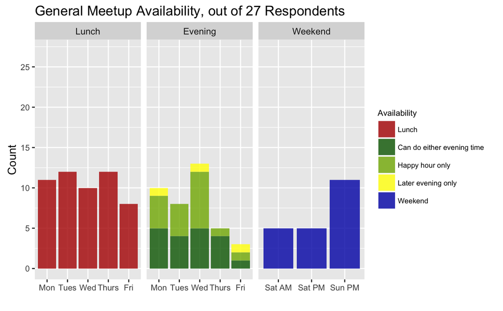

```r
## -- Data management for plotting -----------------------------------------------------------------
meeting_times <- kickoff_data %>%
  ## Only deal with meeting time variables
  select(participant_id, evening_time, sat_am:fri_pm) %>%
  ## Turn into long format
  gather(key = day_time, value = yn, sat_am:fri_pm) %>%
  ## Get separate variables for day, time (lunch, evening, am, pm)
  separate(day_time, into = c('day_week', 'time_day')) %>%
  ## Create factor variables for plotting
  mutate(## Day of the week: M-F, just day names; weekend options need to have time added
         dayvar = factor(ifelse(day_week == 'sat' & time_day == 'am', 1,
                         ifelse(day_week == 'sat' & time_day == 'pm', 2,
                         ifelse(day_week == 'sun', 3,
                         ifelse(day_week == 'mon', 4,
                         ifelse(day_week == 'tues', 5,
                         ifelse(day_week == 'wed', 6,
                         ifelse(day_week == 'thurs', 7,
                         ifelse(day_week == 'fri', 8, NA)))))))),
                         levels = 1:8,
                         labels = c('Sat AM', 'Sat PM', 'Sun PM', 'Mon', 'Tues', 'Wed',
                                    'Thurs', 'Fri')),
         ## Facets: lunch, evening, weekend
         facet_time = factor(ifelse(day_week %in% c('sat', 'sun'), 3,
                             ifelse(time_day == 'pm', 2, 1)),
                             levels = 1:3, labels = c('Lunch', 'Evening', 'Weekend')),
         ## Color by facet and, for evening, whether participants can do both times or just one
         color_scheme = factor(ifelse(facet_time == 'Lunch', 1,
                               ifelse(facet_time == 'Evening' & evening_time == 'Either', 2,
                               ifelse(facet_time == 'Evening' & evening_time == 'Happy hour only', 3,
                               ifelse(facet_time == 'Evening' & evening_time == 'Evening only', 4,
                               ifelse(facet_time == 'Weekend', 5, NA))))),
                               labels = c('Lunch', 'Can do either evening time',
                                          'Happy hour only', 'Later evening only', 'Weekend'))) %>%
  filter(yn == 1)
## -- Create barchart -------------------------------------------------------------------------------
ggplot(data = meeting_times, aes(x = dayvar)) +
  facet_wrap(~ facet_time, nrow = 1, scales = 'free_x') +
  geom_bar(aes(y = ..count.., fill = factor(color_scheme)), alpha = 0.8) +
  scale_x_discrete(name = '') +
  scale_y_continuous(limits = c(0, nrow(kickoff_data)),
                     breaks = seq(0, nrow(kickoff_data), 5),
                     name = 'Count') +
  scale_fill_manual(name = 'Availability',
                    values = c('red' %>% brightness(0.7) %>% saturation(1),
                               gradient(c('darkgreen', 'yellow'), 3),
                               'blue' %>% brightness(0.7) %>% saturation(1))) +
  ggtitle(paste('General Meetup Availability, out of', nrow(kickoff_data), 'Respondents')) +
  theme(plot.title = element_text(hjust = 0),
        axis.text = element_text(size = 8),
        legend.title = element_text(size = 8),
        legend.text = element_text(size = 7))
```

# Preferences for Kickoff Meeting

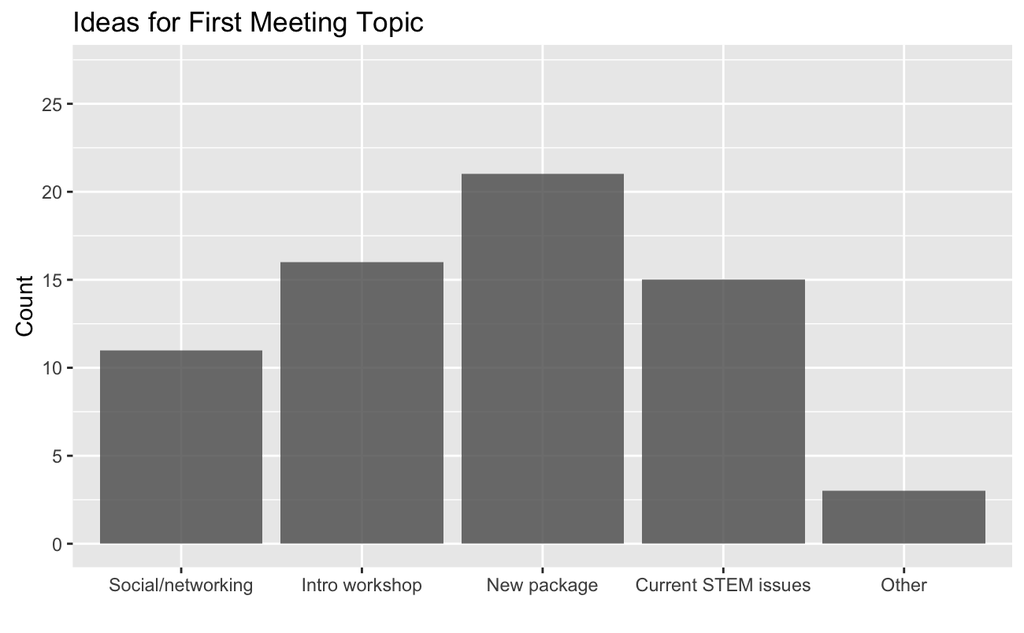

```r
first_mtg_data <- kickoff_data %>%
  select(participant_id, first_mtg_social:first_mtg_other) %>%
  gather(key = topic, value = yn, first_mtg_social:first_mtg_other) %>%
  filter(yn == 1) %>%
  mutate(topic = gsub('first_mtg_', '', topic),
         mtg_topic = factor(ifelse(topic == 'social', 1,
                            ifelse(topic == 'intro', 2,
                            ifelse(topic == 'pkg', 3,
                            ifelse(topic == 'stem', 4, 5)))),
                            levels = 1:5,
                            labels = c('Social/networking',
                                       'Intro workshop',
                                       'New package',
                                       'Current STEM issues',
                                       'Other')))
ggplot(data = first_mtg_data, aes(x = mtg_topic)) +
  geom_bar(aes(y = ..count..), alpha = 0.8) +
  ggtitle('Ideas for First Meeting Topic') +
  scale_x_discrete(name = '') +
  scale_y_continuous(limits = c(0, nrow(kickoff_data)),
                     breaks = seq(0, nrow(kickoff_data), 5),
                     name = 'Count') +
  theme(plot.title = element_text(hjust = 0))
```

### Ideas for “other” topics:

```r
other.topic.ideas <-
  as.list(gsub('\n', ' ',
               subset(kickoff_data, !is.na(first_meeting_other))$first_meeting_other,
               fixed = TRUE))
pander(other.topic.ideas)
```

- Codes examples for graphics,analysis or simulations; Reproducible research advances
- How to involve girls (school age) in programing and other tech activities.
- advanced topics…whatever

### Specific package ideas:

```r
pkg.topic.ideas <-
  as.list(gsub('\n', ' ',
               subset(kickoff_data, !is.na(package_topic))$package_topic,
               fixed = TRUE))
pander(pkg.topic.ideas)
```

- dplyr, data table, matching causal inference and machine learning packages
- tidyr/dplyr
- Tidyverse
- no
- data.table
- data.table

# Meeting Venue Ideas

```r
venue.ideas <-
  as.list(gsub('\n', ' ',
               subset(kickoff_data, !is.na(meeting_venues))$meeting_venues,
               fixed = TRUE))
pander(venue.ideas)
```

- You might reach out to this group and see if they have R users: http://nashvillewomenprogrammers.com/
- Emma (?)
- Atamology?
- Atmalogy has a “boardroom” space available for rent that fits 16 people, in terms of off-campus venues!
- Plan ahead, for a date and depending on how many rsvp –Coffee shops if small group or even dining place –Large group vanderbilt biostatistics large conference room if it is possible
- Coffee shop!
- Vanderbilt SRC There are also meeting rooms in green hills that are available on a per hour basis
- Maybe main campus Vanderbilt would have some good conference room spaces. University club or Student center. Not sure if they’re expensive.
- 8th floor of 2525 West End Avenue.

# R-Ladies Demographics

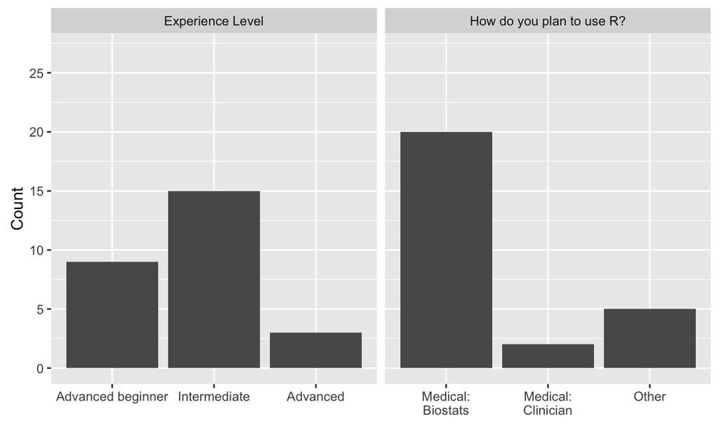

```r
demog_data <- kickoff_data %>%
  select(participant_id, experience_level, how_you_use) %>%
  gather(key = characteristic, value = choice, experience_level:how_you_use) %>%
  mutate(charac.f = factor(ifelse(characteristic == 'experience_level', 1, 2),
                           levels = 1:2,
                           labels = c('Experience Level', 'How do you plan to use R?')),
         choice = ifelse(characteristic == 'how_you_use', choice + 4, choice),
         choice.f = factor(choice,
                           levels = 1:10,
                           labels = c('Absolute beginner',
                                      'Advanced beginner',
                                      'Intermediate',
                                      'Advanced',
                                      'Medical:\nBiostats',
                                      'Medical:\nClinician',
                                      'Tech industry',
                                      'Business',
                                      'Government',
                                      'Other')))
ggplot(data = demog_data, aes(x = choice.f)) +
  facet_wrap(~ charac.f, scales = 'free_x') +
  geom_bar(aes(y = ..count..)) +
  scale_x_discrete(name = '') +
  scale_y_continuous(limits = c(0, nrow(kickoff_data)),
                     breaks = seq(0, nrow(kickoff_data), 5),
                     name = 'Count')
```

Thanks to our 14 ladies who are interested in serving on the planning committee!